# Визуализация данных и бизнес-аналитика

Как из таблицы сделать понятную историю на примере проекта «Национальная торговая статистика»

**МГИМО/ИЭФ · актуальная статистика внешней торговли**

15 сентября 2026

## План занятия

1. Пять шагов от таблицы к графику: вопрос, срез, метрика, форма, смысл. Разбираем на данных нашего проекта.
2. Что оказалось сложнее, чем ожидалось: особенности сбора торговой статистики и их отражение в цифрах.
3. От отдельного графика к бизнес-аналитике: бюллетень, дашборд, доступ к данным.
4. Разбор примеров: запрос к базе и что из него получается.

[figure not shown]

**Материалы проекта**База, бюллетень, документация и эта презентация.quantviews.github.io/mgimo-foreign-trade

01

Пять шагов от таблицы к истории

Между выгрузкой из базы и фразой «вот что происходит с торговлей» лежит работа, которую не выполняет ни один графический пакет (или ИИ).

## Вот наши данные

| NAPR | PERIOD | STRANA | TNVED | EDIZM | STOIM | NETTO | KOL | SOURCE | TYPE |
| --- | --- | --- | --- | --- | --- | --- | --- | --- | --- |
| ИМ | 2024-06-01 | CN | 8402120000 | — | 69 794 | 2 | NULL | national | fact |
| ИМ | 2024-06-01 | CN | 8402900000 | — | 340 757 | 98 933 | 0 | national | fact |
| ИМ | 2024-06-01 | CN | 8403101000 | — | 11 191 887 | 52 614 | NULL | national | fact |
| ЭК | 2019-01-01 | AD | 2208600000 | — | 6 380,6 | 1 380,0 | NULL | comtrade | fact |
| ИМ | 2019-01-01 | AD | 4202210000 | — | 1 188,8 | 12,9 | NULL | comtrade | fact |
| ИМ | 2024-01-01 | GE | 2204210000 | ЛИТР | 13 272 667 | 5 047 930 | 5 047 930 | comtrade | fact |
| ЭК | 2026-07-01 | IN | 2709001000 | — | 6 485 607 679 | 11 530 164 600 | NULL | nowcast | pred |

Семь строк из `unified_trade_data`. Вопрос залу: что здесь происходит с российской торговлей — она растёт или падает?

## Почему таблицу не читают

7 059 418строк в базе

141страна-партнёр

17 839кодов ТН ВЭД

91месяц, 2019–2026

В таблице не читают, а ищут, и для поиска нужно заранее знать, что искать.

Глаз хорошо оценивает длину, положение и направление, но плохо — числа. Визуализация переводит данные из первого режима во второй.

Отсюда простое следствие: график отвечает на вопрос «что происходит», таблица — на вопрос «чему равно». Обе формы нужны, и подменять одну другой не стоит.

## Пять шагов

1. **Вопрос.** На что должен ответить график: объект, метрика, период, база сравнения.
2. **Срез.** Какие строки берём и на каком уровне детализации сворачиваем.
3. **Метрика.** Что измеряем: доллары, тонны или расчётный индекс.
4. **Форма.** Какой тип графика отвечает на такой тип вопроса.
5. **Смысл.** Заголовок, акцент, обозначение того, чего в данных нет.

## Шаг 1. Вопрос

вопрос · срез · метрика · форма · смысл

Рабочая формулировка содержит объект, метрику, период и базу сравнения. Всё, чего в ней не хватает, вы додумаете за читателя.

1. **«Покажи данные по Китаю»**. Не заданы ни период, ни метрика, ни направление торговли. *Лучше:* как изменился физический объём импорта из Китая за последние 12 месяцев по сравнению с предыдущими двенадцатью.
2. **«Растёт ли торговля»**. Торговля чем, с кем и в чём измеренная. *Лучше:* в каких товарных группах экспорт в Индию сократился в тоннах сильнее всего за последний год.
3. **«Сделай дашборд по внешней торговле»**. Нет адресата и нет решения, которое он принимает. *Лучше:* аналитику нужно каждый месяц видеть партнёров, у которых поставки отклонились от прошлого года более чем на 15%.

## Тип вопроса задаёт форму

| Вопрос звучит как… | Что показываем | Форма |
| --- | --- | --- |
| Как менялось со временем | динамику одной или нескольких величин | линия, площадь |
| Кто больше, кто меньше | сравнение категорий между собой | отсортированные горизонтальные столбцы |
| Из чего это состоит | вклад частей в целое | столбцы с накоплением |
| Связано ли одно с другим | две величины по одним объектам | точечная диаграмма |
| Чему равно вот это конкретно | точные значения, которые будут копировать | таблица |

## Шаг 2. Срез

вопрос · срез · метрика · форма · смысл

Как менялась стоимость импорта из Китая в долларах с 2024 года?

```sql
SELECT PERIOD, TNVED2, SUM(STOIM) AS import_usd   -- TNVED2 / TNVED4 / TNVED6 / TNVED
FROM unified_trade_data
WHERE STRANA = 'CN' AND NAPR = 'ИМ' AND TYPE = 'fact'
  AND PERIOD >= DATE '2024-01-01'
GROUP BY 1, 2
```

| Уровень | Кодов в срезе | Строк в ответе | Сумма импорта | Что с этим можно делать |
| --- | --- | --- | --- | --- |
| ТН ВЭД-2 | 98 товарных групп | 2 999 | 292,2 млрд $ | помещается на один график |
| ТН ВЭД-4 | 1 100 позиций | 29 456 | 292,2 млрд $ | уже только таблица |
| ТН ВЭД-6 | 4 455 субпозиций | 108 539 | 292,2 млрд $ | только поиск по коду |
| полный код | 6 777 позиций | 152 150 | 292,2 млрд $ | это выгрузка, а не срез |

Ответить можно на четырёх уровнях детализации: запрос отличается одним словом, а сумма импорта во всех четырёх случаях одна и та же. Меняется только подробность разбивки, поэтому уровень выбирают под то, что читатель способен удержать: 98 групп можно обсудить вслух, 6 777 кодов — только искать в них нужную позицию.

## Что делать с 98 товарными группами

как получается по умолчанию

[figure not shown]

Формально показаны все 98 групп. Практически не читается ни одна, а легенда занимает треть площади.

после выбора истории

[figure not shown]

Те же 98 групп и та же ось. Три линии вынесены вперёд, остальные оставлены фоном: контекст сохранён, а история появилась.

## Шаг 3. Метрика

вопрос · срез · метрика · форма · смысл

[figure not shown]

## Почему нельзя просто сложить количество

Единицы измерения внутри товарной группы 27 (топливо), поле `KOL`:

| EDIZM — единица измерения | строк | SUM(KOL) |
| --- | --- | --- |
| КУБИЧЕСКИЙ МЕТР | 756 | 1 028 176 278 890 |
| ЛИТР | 1 867 | 76 270 871 480 |
| 1000 КИЛОВАТТ-ЧАС | 706 | 54 257 753 |
| 1000 ЛИТРОВ | 158 | 5 549 015 |
| 1000 КУБИЧЕСКИХ МЕТРОВ | 30 | 46 664 880 |
| КВАДРАТНЫЙ МЕТР | 1 | 1 324 000 000 |
| ШТУКА | 33 | 5 391 568 |
| МЕТР | 1 | 9 007 |

`SUM(KOL)` по группе 27 складывает кубометры с киловатт-часами и квадратными метрами. SQL выполнит это и вернёт число; на графике оно будет неотличимо от осмысленного.

## Индекс физического объёма

Нужной метрики в данных нет Стоимость в долларах есть всегда, но она смешивает цену и объём. Натуральные единицы есть, но несопоставимы между собой.

Как считаем Каждую позицию нормируем к её базовому периоду, агрегируем уже безразмерные величины, скользящее окно в 12 месяцев снимает сезонность.

Что это даёт Появляется ответ на вопрос «груза стало больше или меньше» — по любой стране и любому уровню ТН ВЭД. В TradeMap и Comtrade такого показателя нет.

Метрику не всегда выбирают из готовых, иногда её приходится построить. Это часть работы над графиком, а не отдельная математика до неё.

## Метрику диктуют данные

100%строк имеют стоимость STOIM

92%фактических строк имеют вес нетто NETTO

33%фактических строк имеют количество KOL

График, построенный на `KOL`, молча отбросит две трети торговли и никак этого не покажет. Пропуски вообще не видны на картинке: линия просто идёт ниже, и выглядит это как сокращение поставок.

Поэтому индекс в проекте считается на `NETTO`, а `KOL` используется там, где он заполнен. Перед тем как строить график, полезно отдельно посчитать, сколько строк отвалилось на выбранном срезе.

## Шаг 4. Форма

вопрос · срез · метрика · форма · смысл

пирог

[figure not shown]

Сегменты 2,2%, 2,2% и 2,1% на глаз неразличимы, порядок алфавитный, а на каждый сегмент нужен отдельный взгляд в легенду.

столбцы

[figure not shown]

Длина сравнивается точнее угла, сортировка задаёт порядок чтения, доли подписаны, цветом выделено то, о чём идёт речь.

## Итог скрывает, что состав изменился

итог

[figure not shown]

По этому графику вывод такой: в 2022 году был пик, затем спад, сейчас около 41 млрд долларов. Всё верно и мимо главного.

по странам-получателям

[figure not shown]

Те же числа в разбивке. Итог вырос на пятую часть, а состав торговли изменился полностью.

## Ось решает, что читатель увидит

ось обрезана

[figure not shown]

Ось начинается с 25 млрд долларов. Столбцы отличаются в разы визуально и наполовину фактически.

ось от нуля

[figure not shown]

Те же числа. Снижение видно, но в реальном масштабе: как колебание внутри коридора, а не как обвал.

## Цвет

Цвет должен что-то означать Цвет ставят там, где он кодирует категорию, знак или акцент. Раскрашивать всё подряд — то же самое, что выделить жирным весь текст.

Больше пяти цветов не работают Человек надёжно различает пять-семь цветов, дальше начинается сверка с легендой. Остальное уводят в серый, в отдельные панели или в таблицу.

Проверка в градациях серого Около 8% мужчин не различают красный и зелёный, а проектор искажает цвета. График, который читается в чёрно-белом виде, читается везде.

## Шаг 5. Смысл

вопрос · срез · метрика · форма · смысл

заголовок описывает

[figure not shown]

Заголовок пересказывает оси, три линии равноправны, названия рядов взяты из полей базы. Вывод предлагается сделать читателю.

заголовок объясняет

[figure not shown]

Те же данные и те же оси. Заголовок называет вывод, цвет ведёт к нему взгляд, подпись стоит там, куда читатель смотрит.

## Прогноз должен выглядеть как прогноз

[figure not shown]

## Чек-лист перед публикацией

1. **Вопрос сформулирован**объект, метрика, период, база сравнения
2. **Известно, что пропало**сколько строк потерял срез и почему
3. **Метрика названа явно**доллары, тонны или индекс — и это написано
4. **Форма соответствует вопросу**динамика линией, сравнение столбцами
5. **У столбцов ось от нуля**у линии обрезанная ось подписана
6. **Заголовок объясняет**а не пересказывает подписи осей
7. **Цветов не больше пяти**остальное серым, контекстом
8. **Источник и дата указаны**видно, где факт, а где оценка

02

Что оказалось сложнее, чем ожидалось

Прежде чем данные попадут на график, их нужно получить. На этом этапе нас ждало несколько неожиданностей, о которых стоит рассказать отдельно.

## Данные не отдают, их добывают

Китай Портал таможенной службы закрыт капчей, которую приходится решать вручную. Сбор устроен как полуавтомат: скрипт открывает браузер, оператор заполняет форму и скачивает файл, дальше обработка идёт сама.

Выгрузку легко получить в юанях вместо долларов, поэтому валюта проверяется отдельно.

Индия Открытого API нет, есть форма с CSRF-токеном, который нужно получать отдельным запросом. Ответ приходит HTML-страницей и разбирается парсером.

Стоимость в долларах, стоимость в рупиях и количество — три независимых запроса, результаты склеиваются по коду товара.

Турция Данных как файла нет вообще: они живут внутри BI-дашборда, а его движок закрыт от всего, что не браузер. На любой обычный запрос шлюз отвечает одинаковой заглушкой.

Сбор идёт через настоящий Chromium: дожидаемся загрузки дашборда и спрашиваем данные у движка напрямую, минуя интерфейс. Кликать по кнопкам нельзя, такой сбор разваливается при первом изменении вёрстки.

## Пустая таблица и таблица из нулей

Индийская база возвращает структуру таблицы и для тех месяцев, которые ещё не опубликованы: строки на месте, суммы нулевые. Формально ответ корректен, и без проверки такой месяц попал бы в базу как месяц с нулевой торговлей.

На графике это выглядело бы не как отсутствие данных, а как обвал поставок до нуля с последующим восстановлением — то есть как содержательный экономический сюжет.

Сейчас перед записью проверяется сумма по месяцу: если `STOIM` и `KOL` в сумме дают ноль, месяц не сохраняется. Проверок такого рода в пайплайне около десятка, и почти каждая появилась после разбора конкретной странности в данных.

## Ответ обрезается молча

Comtrade принимает параметр `maxRecords`, который ограничивает размер ответа. Признака обрезки в ответе нет, а поле `count` содержит число возвращённых строк, а не действительное их количество.

С исходным лимитом в 50 000 строк экспорт Германии упирался в потолок в 38 парах «страна-месяц». За февраль 2020 года в файл попало ровно 50 000 строк при фактических 61 078 — потери около 18% без единого сообщения об ошибке.

Диагностика оказалась простой: искать месяцы, где число строк в точности равно лимиту. Сейчас лимит 250 000, а совпадение с ним трактуется как обрезка — пачка делится пополам и запрашивается заново.

## Данные меняются задним числом

| Месяц | Стран в нашем файле | Доступно в источнике | Пересмотрели после загрузки |
| --- | --- | --- | --- |
| июнь 2019 | 119 | 129 | 1 |
| июнь 2023 | 120 | 120 | 9 |
| июнь 2025 | 68 | 95 | 51 |

Страны досылают и правят отчётность годами. Январь 2024 года у Андорры впервые опубликован в феврале 2024-го, а последний раз правился в августе 2026-го.

Привычное правило «перекачивать последние N месяцев» здесь не работает: глубина пересмотра разная от месяца к месяцу, а пропуски встречаются и в данных 2019 года. Пришлось хранить рядом с выгрузкой манифест: по каждому месяцу — какие страны в нём есть и какая у их данных контрольная сумма.

## Цена одной буквы

Китай в одном из скриптов записывался кодом `CH`, а в другом — `CN`. В справочнике Comtrade `CH` — это Швейцария.

При сборке базы действует правило: если по стране есть национальная статистика, данные Comtrade по ней не берутся. Из-за расхождения в коде из выгрузки исключалась Швейцария, а Китай не исключался, и китайские данные попадали в базу дважды — из национального источника и из Comtrade.

На графике удвоение не выглядит как ошибка: линия просто идёт выше. Заметить это можно только сверкой с внешним источником или проверкой на уровне данных — поэтому в проекте есть отдельный набор тестов качества, которые считают такие вещи после каждой пересборки.

## Что из этого следует для графика

Ни одна из перечисленных проблем не оставляет следа на картинке. Обрезанный ответ, неопубликованный месяц, задвоенная страна, перепутанное направление — всё это даёт нормально выглядящую линию, которая идёт не туда.

Поэтому вопрос «откуда взялась эта цифра» — не бюрократическая формальность, а часть работы с визуализацией. В базе у каждой записи хранится источник (`SOURCE`) и тип (`TYPE`), а сборка сопровождается тестами качества.

Практический вывод для аналитика: прежде чем объяснять необычное движение на графике экономическими причинами, стоит проверить, не объясняется ли оно способом сбора данных.

03

От графика к бизнес-аналитике

Отдельный хороший график — разовый результат. Бизнес-аналитика начинается там, где он воспроизводится каждый месяц без участия автора.

## Четыре уровня

1. **Разовый график *— Excel, ноутбук, скриншот в презентацию***Отвечает на вопрос один раз. Через месяц данные обновились, и всё нужно повторять руками. Как именно это было сделано, помнит только автор.
2. **Воспроизводимый отчёт *— Quarto-бюллетень проекта***График описан кодом. Пересчёт — одна команда, результат идентичен. Появляется история изменений и возможность проверить, откуда взялась цифра.
3. **Дашборд *— Superset поверх DuckDB***Читатель сам меняет период, страну и товарную группу. Автор отвечает не на один вопрос, а на класс вопросов, и перестаёт быть нужным для каждого среза.
4. **Доступ к данным *— API проекта, выгрузка в Excel и Power Query***Пользователь строит свои графики в своём инструменте. В каком-то смысле это высшая форма визуализации: её делает уже не аналитик, а сам потребитель.

## Страновой бюллетень

Второй уровень из этой лестницы у нас уже работает: ежемесячный выпуск по каждой из трёх стран, три страницы А4, пересборка одной командой.

Торговля с Китаем, из свежего выпуска

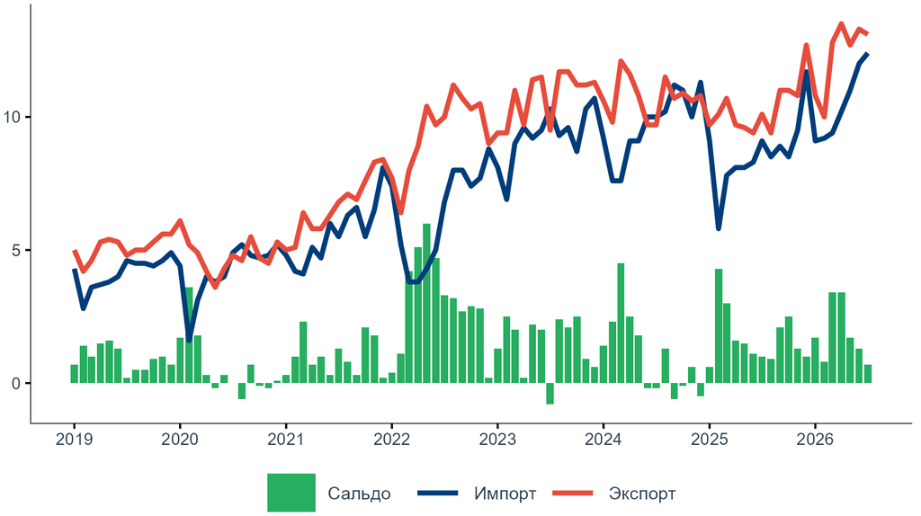

Что внутри

- первая страница: ключевые цифры месяца, сальдо, экспорт нефти
- вторая: изменение экспорта и импорта по товарным категориям за 12 месяцев
- третья: «как читать этот бюллетень», объяснение показателей обычными словами

Третья страница появилась не сразу. Выпуск читают не только экономисты, и без неё половина показателей оставалась непонятной.

## Что в бюллетене сделала программа

Собирается само Цифры месяца, изменения к прошлому месяцу и к прошлому году, все четыре графика, вёрстка страниц, доля наукаста в оценке. Выпуск пересобирается одной командой, когда приходят новые данные.

Это ровно те четыре шага, которые мы разбирали: срез, метрика, форма и даже заголовок.

Не делает никто Фразы во врезках «Главное» стоят в шаблоне: «в основном энергоносители», «импорт растёт быстрее». Они верны, пока общая картина не изменилась, но никто не переписывает их каждый месяц.

И ни одна из них не отвечает на вопрос, почему конкретная цифра сдвинулась именно сейчас.

Получается корректный отчёт, в котором нет ни одного собственного наблюдения. Пятый шаг, смысл, программа за автора не делает.

## Отчёт и дашборд решают разные задачи

|  | Отчёт, бюллетень | Дашборд |
| --- | --- | --- |
| Задача | рассказать историю | дать возможность найти свою |
| Автор вывода | аналитик | читатель |
| Порядок чтения | задан автором, сверху вниз | произвольный, от фильтра |
| Сколько вопросов | один-два, раскрытых глубоко | класс похожих вопросов |
| Заголовки | содержательные: «экспорт сменил адрес» | нейтральные: «экспорт по странам» |
| Частота | выпуск раз в месяц | работает постоянно |
| Типичная неудача | простыня графиков без вывода | тридцать чартов и ни одного фильтра |

## Дашборд проекта

`Внешняя торговля РФ` — пять вкладок поверх одной таблицы. Открывается по адресу инстанса, доступ выдаётся отдельно.

| Вкладка | На какой вопрос отвечает | Чем показано |
| --- | --- | --- |
| Обзор | что со стоимостью и объёмом торговли в целом | итог за 12 месяцев, помесячная динамика, наукаст |
| География | как торговля распределена по странам | области в долларах и в килограммах |
| Продукты | какие товарные группы дают основной объём | treemap по ТН ВЭД и таблица |
| Покрытие | по каким странам и периодам данные вообще есть | матрица покрытия |
| Физобъемы | больше или меньше стало груза | индексы по странам и группам |

## Фильтры: срез делает читатель

панель фильтров дашборда

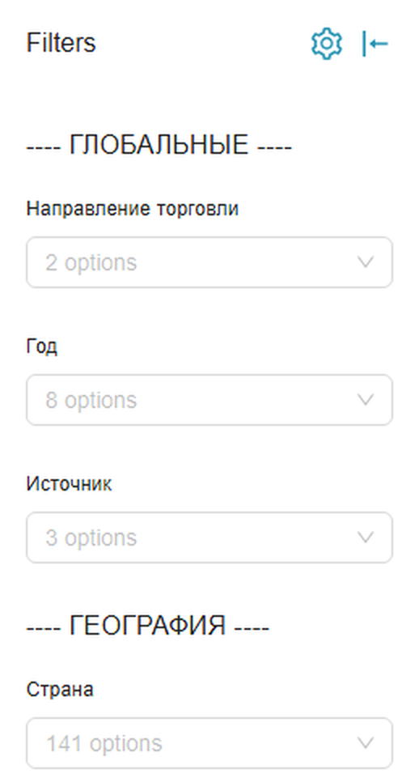

что за ними стоит

| Фильтр | Значений |
| --- | --- |
| Направление торговли | 2 |
| Год | 8 |
| Источник | 3 |
| Страна | 141 |
| ТН ВЭД — 2 знака | 98 |
| ТН ВЭД — 4 знака и полный код | списком с поиском |
| Поиск по названию товара | по-русски |
| Единица измерения | 25 |

Это тот же второй шаг, который в первой части делался запросом: выбор строк и уровня детализации. Разница в том, кто его делает. В отчёте срез выбирает автор; в дашборде — читатель, а автор отвечает за то, чтобы любой разумный срез не сломал ни один график.

## Как это устроено в проекте

[output not shown]

Три выхода собраны из одной таблицы. Различает их не источник данных, а ответ на вопрос, кто читает и какое решение принимает.

## Почему график живёт в коде

График в файле Что происходит через месяц:

- данные обновились, всё делается вручную заново
- не видно, откуда взялась цифра
- оформление каждый раз немного другое
- автор ушёл, повторить некому

График в коде Что даёт воспроизводимость:

- пересчёт одной командой на весь выпуск
- от строки базы до пикселя видна вся цепочка
- единый стиль задан один раз в теме
- история изменений хранится в git

04

Разбор примеров

Три запроса к базе и то, что из них получается. Всё, что нужно, — SQL и десяток строк на R.

## Запрос и ответ

запрос

```sql
SELECT STRANA,
       ROUND(SUM(STOIM) / 1e9, 1) AS import_bn
FROM unified_trade_data
WHERE NAPR = 'ИМ' AND TYPE = 'fact'
  AND PERIOD >= DATE '2025-08-01'
GROUP BY STRANA
ORDER BY import_bn DESC
LIMIT 8
```

результат

| STRANA | import_bn |
| --- | --- |
| CN | 119,7 |
| DE | 7,4 |
| TR | 6,7 |
| KZ | 5,7 |
| IN | 4,3 |
| IT | 3,5 |
| UZ | 2,8 |
| CH | 2,7 |

## Один запрос вместо доверия к данным

запрос

```sql
SELECT SOURCE,
       COUNT(*) AS rows,
       ROUND(100.0 * COUNT(NETTO) / COUNT(*), 1) AS netto_pct,
       ROUND(100.0 * COUNT(KOL)   / COUNT(*), 1) AS kol_pct
FROM unified_trade_data
WHERE TYPE = 'fact'
GROUP BY SOURCE
ORDER BY rows DESC
```

результат

| SOURCE | rows | netto | kol |
| --- | --- | --- | --- |
| comtrade | 5 083 529 | 99,1% | 32,6% |
| national | 1 383 855 | 66,8% | 32,3% |

## От запроса к графику

запрос и десять строк на R

```r
ex <- dbGetQuery(con, "
  SELECT PERIOD, SUM(STOIM) / 1e9 AS export_bn
  FROM unified_trade_data
  WHERE STRANA = 'CN' AND NAPR = 'ЭК'
    AND TYPE = 'fact'
    AND PERIOD >= DATE '2022-01-01'
  GROUP BY PERIOD ORDER BY PERIOD")

ggplot(ex, aes(PERIOD, export_bn)) +
  geom_line(linewidth = 1.2, colour = "#003d7a") +
  scale_y_continuous(limits = c(0, NA)) +
  labs(title = "Экспорт в Китай:
       около 12 млрд $ в месяц",
       x = NULL, y = "млрд $") +
  theme_minimal()
```

результат

[figure not shown]

## Что стоит запомнить

1. **Вопрос.** Без него любая картинка одинаково бессмысленна.
2. **Срез.** Агрегация выбирает уровень разговора, а не теряет данные.
3. **Метрика.** Доллары и тонны дают разные выводы об одной и той же торговле.
4. **Форма.** Тип графика определяется вопросом.
5. **Смысл.** Заголовок объясняет, а не пересказывает оси.
6. **Происхождение.** Странное движение на графике сначала проверяют на ошибку сбора.

Понятная история — это цепочка решений о том, что показать, чем измерить и что назвать главным. Графический пакет выполняет только последний шаг.

## Ищем человека, который это объяснит

В бюллетене по Китаю четырнадцать товарных категорий, и почти каждая строка это вопрос без ответа.

Вопросы из последнего выпуска За 12 месяцев в экспорте в Китай:

- медные концентраты прибавили 3,5 млрд долларов
- золото прибавило столько же
- платина необработанная выросла вдвое
- уголь потерял 0,6 млрд, нефтепродукты почти 1 млрд

Почему выросли именно концентраты, а не рафинированная медь? Это разовые поставки или смена структуры?

Что предлагаем Разбирать такие случаи по одному и писать короткий содержательный комментарий к выпуску. Начать можно с одной категории и одной страны.

Даём доступ к базе, к дашборду и к выгрузкам, показываем, как устроен пересчёт. Комментарий выходит за вашей подписью в составе выпуска.

Задача не учебная: бюллетень читают за пределами университета, и от того, есть ли в нём живой разбор, зависит, читают ли его вообще. Если интересно, напишите: m_salihov@fief.ru.

Национальная торговая статистика База данных · API · бюллетень · дашборд

[figure not shown]

**quantviews.github.io/mgimo-foreign-trade**Материалы проекта и эта презентация